# Naive multi-objective optimization

## Dependencies

There are some packages we use for data manipulation (e.g. magrittr and dplyr) that can be quickly installed by installing tidyverse. We also use the mco package for performing true [multi-objective optimization](https://en.wikipedia.org/wiki/Multi-objective_optimization) to obtain [Pareto optimality](https://en.wikipedia.org/wiki/Pareto_efficiency).

```r
# install.packages(c("tidyverse", "mco"))
library(magrittr)
```

## Data

> [hyperopt_results_1-initial.csv](https://phabricator.wikimedia.org/P5418) has an initial tuning where i ran 10 iterations to find an eta for 100 trees, so i can tune other parameters with reasonably fast training rate, and then [hyperopt_results_1-final.csv](https://phabricator.wikimedia.org/P5419) which is run after tuning all the other params with 625 trees to build a final model

Since **hyperopt_results_1-final.csv** has more data to work with, let’s go with that one.

```r
hyperopt_results <- readr::read_csv("https://phab.wmfusercontent.org/file/data/6bti3vwy6y2y45hkveps/PHID-FILE-ap3xylgefinjtf3fa5f7/hyperopt_results_1-final.csv")
head(hyperopt_results)
```

| id | eta | ndcg@10 | ndcg@10_variance | true_loss | true_loss_variance |
| --- | --- | --- | --- | --- | --- |
| 0 | 0.16 | 0.8363042 | 2.25e-05 | 0.0056234 | 3.25e-05 |
| 1 | 0.13 | 0.8361805 | 2.11e-05 | 0.0050398 | 2.89e-05 |
| 2 | 0.17 | 0.8364635 | 2.39e-05 | 0.0056227 | 3.36e-05 |
| 3 | 0.26 | 0.8365172 | 2.18e-05 | 0.0068038 | 3.09e-05 |
| 4 | 0.23 | 0.8365293 | 2.26e-05 | 0.0063705 | 3.10e-05 |
| 5 | 0.08 | 0.8353303 | 2.22e-05 | 0.0036227 | 3.09e-05 |

It’s worth noting that are are multiple results for certain values of $\eta$:

```r
table(hyperopt_results$eta)
```

| 0.01 | 0.02 | 0.05 | 0.06 | 0.08 | 0.1 | 0.11 | 0.13 | 0.14 | 0.15 | 0.16 | 0.17 | 0.18 | 0.19 | 0.2 | 0.21 | 0.22 | 0.23 | 0.24 | 0.25 | 0.26 | 0.27 | 0.28 | 0.29 | 0.3 |
| --- | --- | --- | --- | --- | --- | --- | --- | --- | --- | --- | --- | --- | --- | --- | --- | --- | --- | --- | --- | --- | --- | --- | --- | --- |
| 1 | 1 | 1 | 1 | 1 | 1 | 1 | 3 | 1 | 1 | 3 | 2 | 2 | 1 | 1 | 3 | 2 | 3 | 3 | 3 | 4 | 3 | 2 | 4 | 2 |

## Multi-objective optimization

Let’s optimize `foo`, which will have one input ($\eta$) and 2 outputs (objectives): `ndcg@10` and `true_loss`. Since `ndcg@10` needs to be maximized, we negate `ndcg@10` so that `-ndcg@10` is minimized along with `true_loss`:

```r
foo <- function(x) {
  # multi-objective function to minimize
  idx <- which.min(abs(hyperopt_results$eta - x))
  y <- apply(hyperopt_results[idx, c(3, 5), drop = FALSE], 2, mean)
  y[1] <- -y[1]
  return(y)
}
set.seed(0)
algorithm <- mco::nsga2(
  foo, 1, 2,
  lower.bounds = min(hyperopt_results$eta),
  upper.bounds = max(hyperopt_results$eta)
)
```

Then we put the results into a structure that’s easier to work with:

```r
moo_results <- data.frame(
  eta = algorithm$par[algorithm$pareto.optimal, 1, drop = TRUE],
  ndcg10 = -algorithm$value[algorithm$pareto.optimal, 1, drop = TRUE],
  true_loss = algorithm$value[algorithm$pareto.optimal, 2, drop = TRUE]
) %>%
  dplyr::distinct(ndcg10, true_loss, .keep_all = TRUE) %>%
  dplyr::arrange(eta)
moo_results$derivative = c(NA, (moo_results$ndcg10[-1] - moo_results$ndcg10[-nrow(moo_results)])/(moo_results$true_loss[-1] - moo_results$true_loss[-nrow(moo_results)]))
```

```r
head(moo_results)
```

| eta | ndcg10 | true_loss | derivative |
| --- | --- | --- | --- |
| 0.0107567 | 0.8136702 | 0.0021551 | NA |
| 0.0175213 | 0.8249952 | 0.0025317 | 30.0685641 |
| 0.0653762 | 0.8340424 | 0.0031105 | 15.6320409 |
| 0.0837484 | 0.8353303 | 0.0036227 | 2.5143746 |
| 0.0994235 | 0.8358589 | 0.0039672 | 1.5339912 |
| 0.1243014 | 0.8361805 | 0.0050398 | 0.2998697 |

We calculate the derivative of curve because we can use that to find the point at which we’re increasing the loss faster than we are increasing `ndcg@10`:

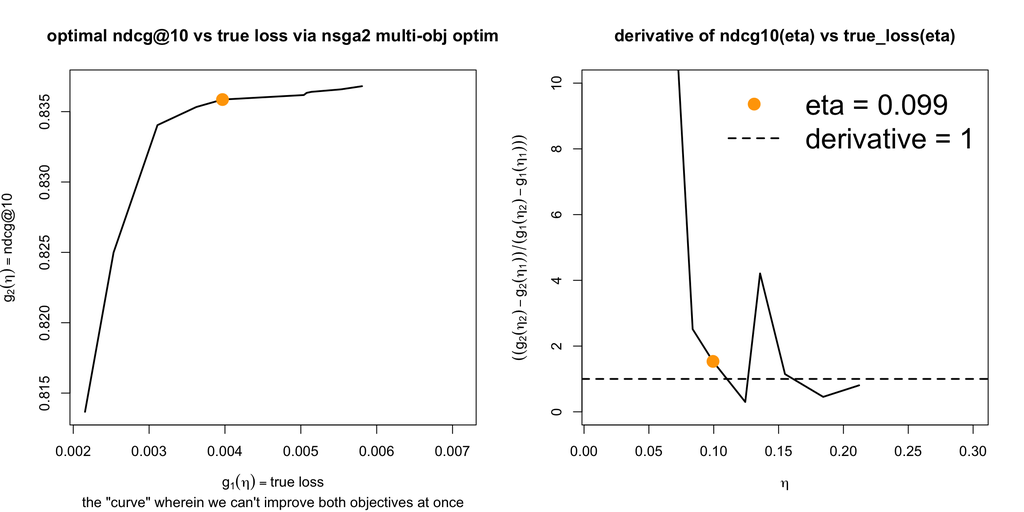

## Fast naive approach

Let’s use lowess (`loess`) smoothing to get $f_\text{ndcg10}(\eta)$ and $f_\text{loss}(\eta)$. We use R’s `predict.loess` function to get fitted values and the standard errors, which will be useful later.

```r
etas <- seq(min(hyperopt_results$eta), max(hyperopt_results$eta), length.out = 1e4)
ndcg10 <- loess(`ndcg@10` ~ eta, data = hyperopt_results, span = 0.5) %>%
  predict(data.frame(eta = etas), se = TRUE) %>%
  {.[c("fit", "se.fit")]} %>%
  do.call(cbind, .) %>%
  as.data.frame %>%
  dplyr::mutate(
    lower_se = fit - se.fit,
    upper_se = fit + se.fit,
    lower_95 = fit - 1.96 * se.fit,
    upper_95 = fit + 1.96 * se.fit
  )
true_loss <- loess(true_loss ~ eta, data = hyperopt_results, span = 2) %>%
  predict(data.frame(eta = etas), se = TRUE) %>%
  {.[c("fit", "se.fit")]} %>%
  do.call(cbind, .) %>%
  as.data.frame %>%
  dplyr::mutate(
    lower_se = fit - se.fit,
    upper_se = fit + se.fit,
    lower_95 = fit - 1.96 * se.fit,
    upper_95 = fit + 1.96 * se.fit
  )
```

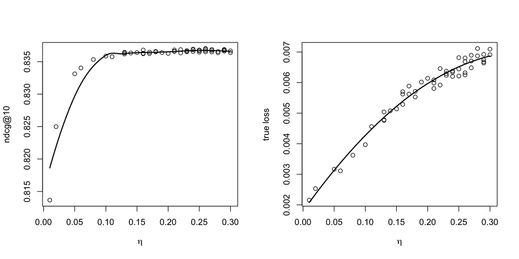

```r
derivative <- c(NA, (ndcg10$fit[-1] - ndcg10$fit[-nrow(ndcg10)])/(true_loss$fit[-1] - true_loss$fit[-nrow(true_loss)]))
idx <- unname(head(which(derivative < 1), 1)) - 1
```

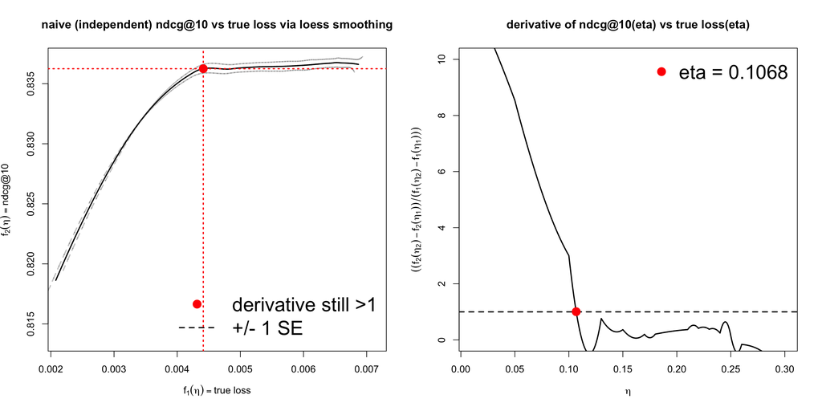

```r
idx_ser_x <- which.min(abs(true_loss$lower_se - true_loss$fit[idx]))
idx_ser_y <- which.min(abs(ndcg10$fit - ndcg10$lower_se[idx_ser_x]))
```

```r
dplyr::data_frame(
  point = c(rep("red", 3), rep("blue", 3)),
  key = rep(c("eta", "true loss", "ndcg@10"), 2),
  value = round(c(
    etas[idx], true_loss$fit[idx], ndcg10$fit[idx],
    etas[idx_ser_y], true_loss$fit[idx_ser_y], ndcg10$fit[idx_ser_y]
  ), 4)
)
```

| point | key | value |
| --- | --- | --- |
| red | eta | 0.1068 |
| red | true loss | 0.0044 |
| red | ndcg@10 | 0.8362 |
| blue | eta | 0.0985 |
| blue | true loss | 0.0042 |
| blue | ndcg@10 | 0.8359 |

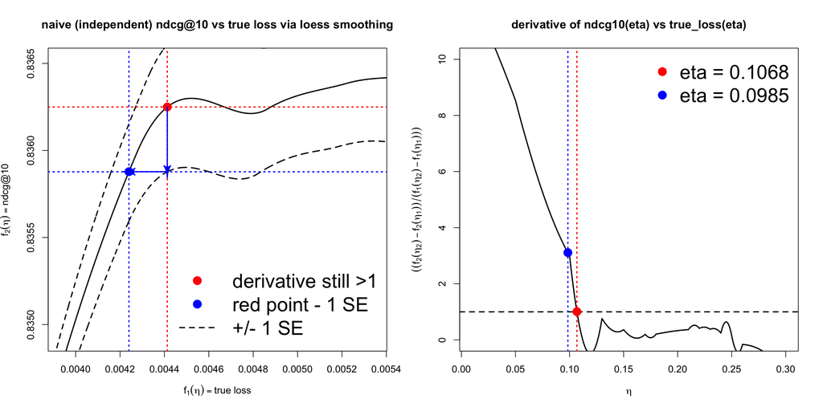